# Face Recognition

## Introduction to OpenCV

**Image processing is performing some operations on images to get an intended manipulation**

###### OpenCV stands for Open Source Computer Vision library and it’s invented by Intel in 1999

```python
import cv2
import matplotlib.pyplot as plt
```

```python
# Read an Image
img = cv2.imread('Face Recognition/exodia_tushar.jpg')
```

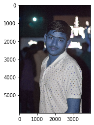

```python
plt.imshow(img)
```

```python
cv2.__version__
```

```
'4.1.0'
```

What we get as an output is a bit different concerning color. We expected a bright colored image but what we obtain is an image with some bluish tinge. That happens because OpenCV and matplotlib have different orders of primary colors. Whereas OpenCV reads images in the form of BGR, matplotlib, on the other hand, follows the order of RGB. Thus, when we read a file through OpenCV, we read it as if it contains channels in the order of blue, green and red. However, when we display the image using matplotlib, the red and blue channel gets swapped and hence the blue tinge. To avoid this issue, we will transform the channel to how matplotlib expects it to be using the cvtColor function.

##### The default setting of the color mode in OpenCV comes in the order of BGR, which is different from that of Matplotlib. Therefore to see the image in RGB mode, we need to convert it from BGR to RGB

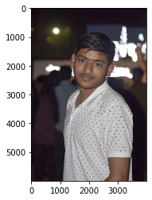

```python
# Convert the image into RGB
img_rgb = cv2.cvtColor(img, cv2.COLOR_BGR2RGB)
plt.imshow(img_rgb)
```

```python
print(img)
```

```
[[[17 11 16]
  [15  9 14]
  [16 10 15]
  ...
  [24 17 22]
  [22 15 20]
  [25 18 23]]

 [[15  9 14]
  [15  9 14]
  [16 10 15]
  ...
  [26 19 24]
  [24 17 22]
  [25 18 23]]

 [[14  8 13]
  [17 11 16]
  [18 11 18]
  ...
  [24 17 22]
  [22 15 20]
  [21 14 19]]

 ...

 [[24 29 38]
  [22 27 36]
  [21 28 37]
  ...
  [36 38 48]
  [35 37 47]
  [37 39 49]]

 [[25 30 39]
  [23 28 37]
  [23 30 39]
  ...
  [37 39 49]
  [34 36 46]
  [35 37 47]]

 [[23 28 37]
  [22 27 36]
  [22 29 38]
  ...
  [41 43 53]
  [41 43 53]
  [36 38 48]]]
```

```python
a=[2,3,4,5]
```

```python
a[-1:]
```

```
[5]
```

## **Images as Arrays**

An image is nothing but a **standard Numpy array** containing pixels of data points. **More** the number of **pixels** in an image, the **better is its resolution**. You can think of pixels to be tiny blocks of information arranged in the form of a 2 D grid, and the **depth of a pixel refers to the color information present in it**

##### A colored image also consists of 8 bits per pixel. As a result, 256 different shades of colors can be represented with 0 denoting black and 255 white. Let us look at the famous colored image of a mandrill which has been cited in many image processing examples.

[figure not shown]

The **cv2.waitKey() is a keyboard binding function**. Its **argument** is the **time in milliseconds**. The function waits for specified milliseconds for any keyboard event. If you press any key in that time, the program continues.

[figure not shown]

As shown, the size of the image here can be calculated as B x A x 3. **Note: For a black-white image, there is only one single channel.**